# Análisis de los resultados del modelado para Grado

En este análisis se realiza un análisis de los resultados obtenidos con el modelo realizado para los alumnos de Grado.

En este sentido, se ha realizado lo siguiente:

1. Se obtienen las métricas del modelo en el conjunto test.
2. Se observa la matriz de confusión para los matriculados y no matriculados, comparando el real con el predicho.
3. Se comparan las tasas de matriculación obtenidas con el predicho y las reales en las 5 principales titulaciones.
4. Se analizan las distribuciones de la probabilidad en cada una de las distintas etapas.
5. Se mira las distribuciones de la probabilidad de matrícula en las 5 titulaciones top.
6. Se mira la importancia de las variables dentro del modelo utilizado.

## 1. Resultados globales del modelo de Grado

```
--------------------------------------------------
      VIRTUDES Y MÉTRICAS DEL MODELO DE ADMISIÓN
--------------------------------------------------
✅ Porcentaje de Acierto (Accuracy): 83.29%
🎯 Capacidad de Discriminación (AUC-ROC): 0.9172
📊 Precisión (Cuando predice Sí, ¿cuánto acierta?): 79.55%
📈 Sensibilidad (¿A cuántos del total captura?): 86.08%
🛡️ Especificidad (Capacidad de detectar No-Matrícula): 80.89%
--------------------------------------------------

ANÁLISIS ESTRATÉGICO:
⭐ El modelo tiene un rendimiento EXCELENTE. La separación entre perfiles es muy clara.
💡 De cada 100 matrículas reales, el modelo identifica correctamente a 86 candidatos.
💡 El modelo es especialmente bueno descartando (Especificidad: 80.89%), lo que ahorra esfuerzo comercial.
--------------------------------------------------
```

El modelo de admisión presenta un rendimiento excelente (AUC: 0.9172), identificando correctamente la mayoría de candidatos y optimizando el esfuerzo comercial gracias a su alta especificidad.

## 2. Matriz de confusión global

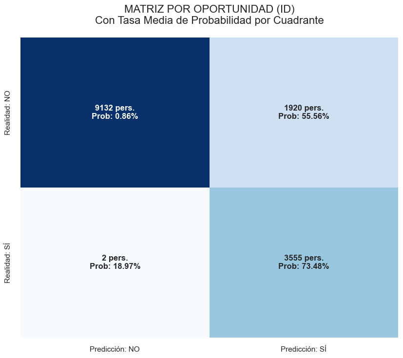

```
Exactitud (Accuracy): 86.84%
Precisión (Certeza de Matrícula): 64.93%
```

El modelo alcanza una exactitud del 86,84% identificando correctamente la mayoría de casos positivos y negativos. El análisis gráfico muestra que asigna altas probabilidades a las predicciones acertadas (73,48% en Matriculados y 0.86% en No matriculados), lo que refleja buena calibración y confianza en sus resultados. También se puede ver que en los casos en los que el modelo predice que se matricula y al final no se matricula, las probabilidades son del 50%, lo que indica que el modelo duda.

## 3. Comparación tasa real de matriculación con la predicha en el top 5 de titulaciones

```
--------------------------------------------------
      VIRTUDES DEL MODELO (SOBRE OPORTUNIDADES ÚNICAS)
--------------------------------------------------
✅ Exactitud Global (Accuracy): 85.58%
🎯 Área bajo la curva (AUC): 0.9276
📊 Precisión de Matrícula: 65.22%
📈 Capacidad de Captación (Recall): 87.35%
--------------------------------------------------
```

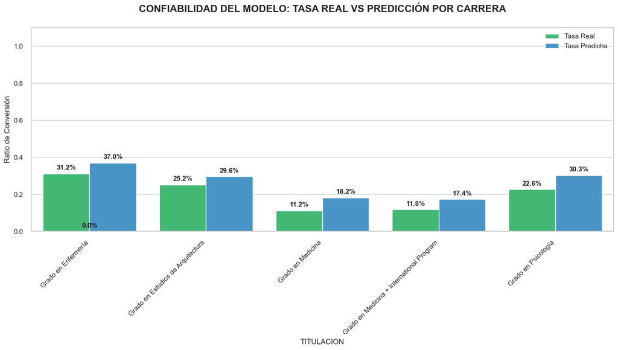

## 4. Evolución de la probabilidad de matrícula por etapa

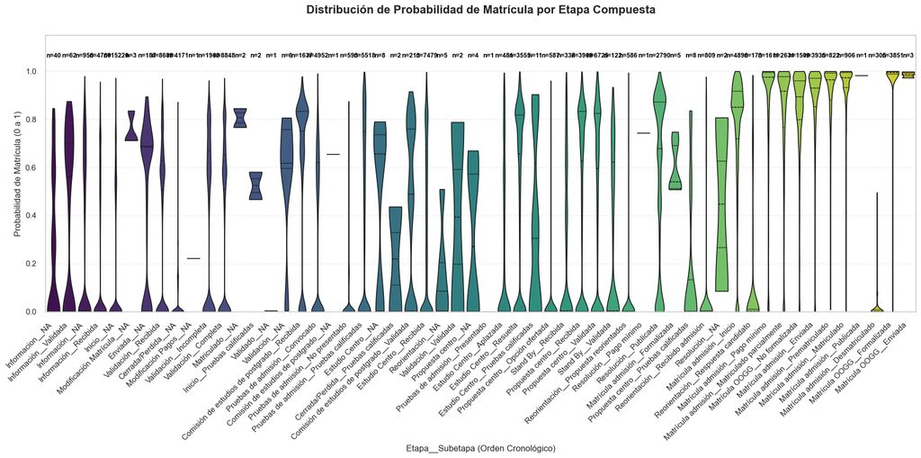

Se pueden observar etapas con probabilidades de matrícula predominantemente bajas, lo que indica menor certeza en esas fases iniciales. En la etapa de Matrícula admisión, las probabilidades se distribuyen de forma más amplia, abarcando tanto valores bajos como altos, reflejando su carácter decisivo. Finalmente, en las etapas previas aMatrícula OOGG, las probabilidades se concentran casi por completo en valores muy altos, evidenciando una elevada certeza de matrícula.

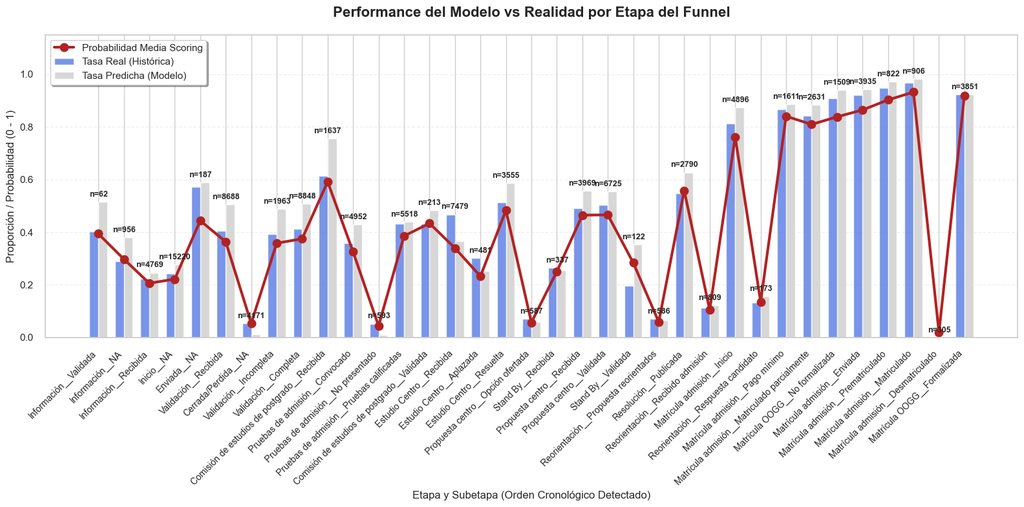

```
📋 RESUMEN DE MÉTRICAS POR ETAPA ORDENADA:
                             etapa_compuesta  tasa_real  prediction_label  prob_matricula_real  num_casos
                       Información__Validada   0.403226          0.516129             0.394135         62
                             Información__NA   0.289749          0.379707             0.297872        956
                       Información__Recibida   0.223737          0.246593             0.206067       4769
                                  Inicio__NA   0.243693          0.276873             0.222003      15220
                                 Enviada__NA   0.572193          0.588235             0.443850        187
                        Validación__Recibida   0.404351          0.505985             0.363718       8688
                         Cerrada/Perdida__NA   0.054184          0.010789             0.053766       4171
                      Validación__Incompleta   0.392766          0.488538             0.358276       1963
                        Validación__Completa   0.413314          0.507798             0.375032       8848
 Comisión de estudios de postgrado__Recibida   0.613928          0.756872             0.591953       1637
              Pruebas de admisión__Convocado   0.358239          0.429927             0.325605       4952
          Pruebas de admisión__No presentado   0.052277          0.010118             0.043843        593
    Pruebas de admisión__Pruebas calificadas   0.430953          0.440196             0.385568       5518
 Comisión de estudios de postgrado__Validada   0.431925          0.483568             0.433785        213
                    Estudio Centro__Recibida   0.467576          0.366359             0.339644       7479
                    Estudio Centro__Aplazada   0.301455          0.253638             0.232644        481
                    Estudio Centro__Resuelta   0.512518          0.586779             0.483215       3555
           Propuesta centro__Opción ofertada   0.069847          0.059625             0.057076        587
                          Stand By__Recibida   0.264095          0.255193             0.250810        337
                  Propuesta centro__Recibida   0.491560          0.557067             0.464920       3969
                  Propuesta centro__Validada   0.502305          0.555688             0.465968       6725
                          Stand By__Validada   0.196721          0.352459             0.283738        122
       Reorientación__Propuesta reorientados   0.071672          0.064846             0.058694        586
                       Resolución__Publicada   0.547670          0.627240             0.557836       2790
            Reorientación__Recibido admisión   0.113721          0.122373             0.104358        809
                  Matrícula admisión__Inicio   0.812704          0.875204             0.761970       4896
          Reorientación__Respuesta candidato   0.132948          0.156069             0.135199        173
             Matrícula admisión__Pago mínimo   0.867163          0.887027             0.840886       1611
Matrícula admisión__Matriculado parcialmente   0.841885          0.884835             0.809677       2631
              Matrícula OOGG__No formalizada   0.907886          0.941683             0.838529       1509
                 Matrícula admisión__Enviada   0.920712          0.943583             0.864711       3935
          Matrícula admisión__Prematriculado   0.947689          0.972019             0.902825        822
             Matrícula admisión__Matriculado   0.967991          0.982340             0.932584        906
          Matrícula admisión__Desmatriculado   0.000000          0.000000             0.018666        305
                 Matrícula OOGG__Formalizada   0.924176          0.923656             0.919852       3851
```

Aquí se puede observar las tasas de matriculación por etapa y subetapa ordenadas, junto a la probabilidad media. Se puede ver que a medida que se va avanzando en las distintas etapas, la probabilidad media va aumentando y que una vez se inicia la admisión, la probabilidad aumenta considerablemente.

También se puede ver que aquellas etapas con probabilidades muy bajas son etapas de desmatriculados, reorientados, no presentados, etc. Lo cual tiene todo el sentido del mundo.

## Distribución de probabilidades en el top 5 de titulaciones

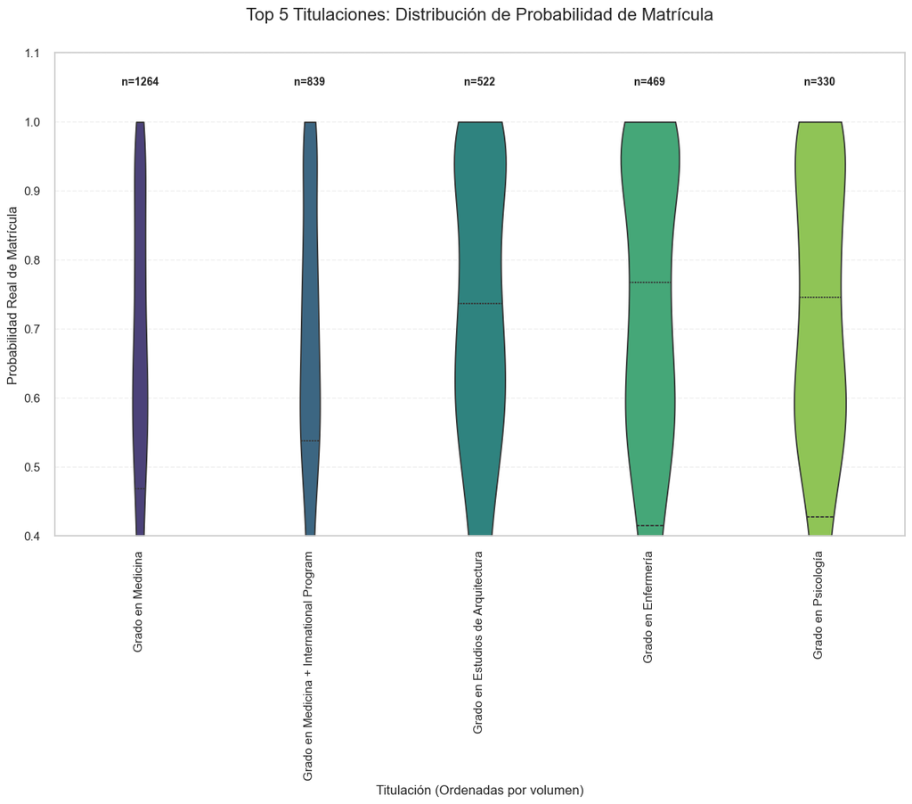

## Importancia de variables

```
Transformation Pipeline and Model Successfully Loaded
```

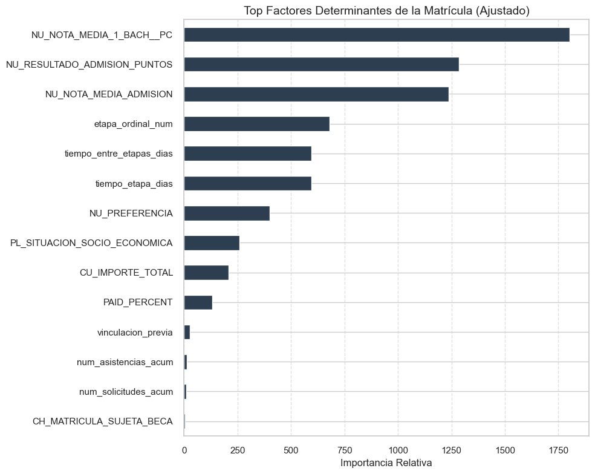

Aquí se puede observar que las variables con mayor peso en la probabilidad de matrícula son:

- Las notas (media de bachillerato y puntuación de admisión).
- Seguidas por la nota media de admisión y el orden/tiempo en el proceso.
- Por último, influyen la preferencia por la titulación, la situación socioeconómica y factores económicos como el importe total y el porcentaje pagado.